# Lab 4: Boosting

GSB 545

```python
import pandas as pd
import numpy as np
import sklearn
```

## Data Preparation

```python
# import heart disease data
heart = pd.read_csv("/content/heart_2020_cleaned.csv")
heart.head(5)
```

|  | HeartDisease | BMI | Smoking | AlcoholDrinking | Stroke | PhysicalHealth | MentalHealth | DiffWalking | Sex | AgeCategory | Race | Diabetic | PhysicalActivity | GenHealth | SleepTime | Asthma | KidneyDisease | SkinCancer |
| --- | --- | --- | --- | --- | --- | --- | --- | --- | --- | --- | --- | --- | --- | --- | --- | --- | --- | --- |
| 0 | No | 16.60 | Yes | No | No | 3.0 | 30.0 | No | Female | 55-59 | White | Yes | Yes | Very good | 5.0 | Yes | No | Yes |
| 1 | No | 20.34 | No | No | Yes | 0.0 | 0.0 | No | Female | 80 or older | White | No | Yes | Very good | 7.0 | No | No | No |
| 2 | No | 26.58 | Yes | No | No | 20.0 | 30.0 | No | Male | 65-69 | White | Yes | Yes | Fair | 8.0 | Yes | No | No |
| 3 | No | 24.21 | No | No | No | 0.0 | 0.0 | No | Female | 75-79 | White | No | No | Good | 6.0 | No | No | Yes |
| 4 | No | 23.71 | No | No | No | 28.0 | 0.0 | Yes | Female | 40-44 | White | No | Yes | Very good | 8.0 | No | No | No |

```python
# examine column types
heart.dtypes
```

```
HeartDisease         object
BMI                 float64
Smoking              object
AlcoholDrinking      object
Stroke               object
PhysicalHealth      float64
MentalHealth        float64
DiffWalking          object
Sex                  object
AgeCategory          object
Race                 object
Diabetic             object
PhysicalActivity     object
GenHealth            object
SleepTime           float64
Asthma               object
KidneyDisease        object
SkinCancer           object
dtype: object
```

```python
# code categorical character variables to numbers
from sklearn.preprocessing import LabelEncoder
le = LabelEncoder()

for col in heart:
  if heart[col].dtypes == 'object':
    heart[col] = le.fit_transform(heart[col])

# for binary variables, 0 = no, 1 = yes
```

```python
heart.head(5)
```

|  | HeartDisease | BMI | Smoking | AlcoholDrinking | Stroke | PhysicalHealth | MentalHealth | DiffWalking | Sex | AgeCategory | Race | Diabetic | PhysicalActivity | GenHealth | SleepTime | Asthma | KidneyDisease | SkinCancer |
| --- | --- | --- | --- | --- | --- | --- | --- | --- | --- | --- | --- | --- | --- | --- | --- | --- | --- | --- |
| 0 | 0 | 16.60 | 1 | 0 | 0 | 3.0 | 30.0 | 0 | 0 | 7 | 5 | 2 | 1 | 4 | 5.0 | 1 | 0 | 1 |
| 1 | 0 | 20.34 | 0 | 0 | 1 | 0.0 | 0.0 | 0 | 0 | 12 | 5 | 0 | 1 | 4 | 7.0 | 0 | 0 | 0 |
| 2 | 0 | 26.58 | 1 | 0 | 0 | 20.0 | 30.0 | 0 | 1 | 9 | 5 | 2 | 1 | 1 | 8.0 | 1 | 0 | 0 |
| 3 | 0 | 24.21 | 0 | 0 | 0 | 0.0 | 0.0 | 0 | 0 | 11 | 5 | 0 | 0 | 2 | 6.0 | 0 | 0 | 1 |
| 4 | 0 | 23.71 | 0 | 0 | 0 | 28.0 | 0.0 | 1 | 0 | 4 | 5 | 0 | 1 | 4 | 8.0 | 0 | 0 | 0 |

We will split the dataset into features (X) and the target variable (y): heart disease.

```python
# create input variables (X) and target (y) and convert to array
X = heart.drop(columns = ['HeartDisease'])
y = heart['HeartDisease']
```

We will split the dataset into train and test sets to evaluate our model performance. The test set is 30\% of the data while the train set is 70\% of the data. We stratify on heart disease in the train test split to preserve the same proportions of heart disease as in the original dataset.

```python
# import train_test_split from sklearn.model_selection
# create train test split
from sklearn.model_selection import train_test_split
# split the dataset into train and test set with 70% and 30% respectively
X_train, X_test, y_train, y_test = train_test_split(X, y, test_size=0.3, random_state=4, stratify = y)
```

```python
X_train.shape, y_train.shape
```

```
((223856, 17), (223856,))
```

```python
X_test.shape, y_test.shape
```

```
((95939, 17), (95939,))
```

```python
heart['HeartDisease'].value_counts()
```

```
0    292422
1     27373
Name: HeartDisease, dtype: int64
```

As shown in the above output, within the target variable heart disease, there at 292,422 observations with No and 27,373 observations with Yes heart disease which represents imbalanced data. Imbalanced data will cause problems with our modeling algorithms such as having bias towards the majority class in predictions and possibly treating the minority class as noise, thus misleading accuracy scores. Therefore we will examine oversampling and undersampling techniques.

Oversampling increases the sample size of the minority class by replication to try to match the sample size of the majority class. The oversampling method we will use is SMOTE (Synthetic Minority Oversampling Technique), an algorithm that creates synthetic samples from the minority class rather than copying values.

```python
# import SMOTE from imblearn.over_sampling
from imblearn.over_sampling import SMOTE
from collections import Counter
```

```python
# balance the dataset using SMOTE (oversampling)
smote = SMOTE(sampling_strategy='minority')
X_train_smote , y_train_smote = smote.fit_resample(X_train,y_train)

print('Original: {}'.format(Counter(y_train)))
print('SMOTE: {}'.format(Counter(y_train_smote)))
```

```
Original: Counter({0: 204695, 1: 19161})
SMOTE: Counter({0: 204695, 1: 204695})
```

In the new SMOTE oversampling training set, the size of Yes heart disease (1) has increased to match the size of No heart disease (0) from the original train set.

Undersampling reduces the sample size of the majority class and tries to match it to the sample size of the minority class. The undersampling method we will use is NearMiss, which is a technique that will select majority class examples with minimum distance to each minority class example.

```python
# import NearMiss from imblearn.under_sampling
from imblearn.under_sampling import NearMiss
from collections import Counter
```

```python
# balance the dataset using NearMiss (undersampling)
nearmiss = NearMiss(version=3)
X_train_nearmiss, y_train_nearmiss = nearmiss.fit_resample(X_train, y_train)

print('Original: {}'.format(Counter(y_train)))
print('NearMiss: {}'.format(Counter(y_train_nearmiss)))
```

```
Original: Counter({0: 204695, 1: 19161})
NearMiss: Counter({0: 19161, 1: 19161})
```

In the new undersampling training, the size of No heart disease (0) has decreased to match the size of Yes heart disease (1) from the original train set.

## Predicting Heart Disease

We will explore three different classification models to predict heart disease: XGBoost, AdaBoost, and Random forest classifier (bagging algorithm). Model performance will be determined by precision and recall metrics because the data is imbalanced.

In this scenario, precision is the proportion of adults that we correctly identify as having a heart disease out of all the adults that were classified as having a heart disease. Recall is the proportion of adults that we correctly identify as having a heart disease out of all adults who actually have heart disease. We must take into consideration the trade-off between precision and recall as both can't be high at the same time. For this dataset, we might consider a model achieving higher recall is more important that getting high precision because we would like to detect as many adults with heart disease.

### XGBoost

We will evaluate various XGBoost classification models with different parameters to determine which model has the best precision-recall tradeoff. Model 5 is found to be the best performing XGBoost model.

```python
# import xgboost classification model
from xgboost import XGBClassifier
from sklearn.tree import DecisionTreeClassifier

from sklearn.metrics import confusion_matrix, classification_report
```

#### Model 1

XGBoost classification model with scale_pos_weight defined to control the balance of majority and minority weights. The value was determined by the ratio of the sum of majority vs minority cases.

Model 1 with SMOTE training set

```python
# specify model 1
model1 = XGBClassifier(scale_pos_weight = 10)

# train the model on oversample training set
model1.fit(X_train_smote, y_train_smote)
y_pred1 = model1.predict(X_test)
```

```python
# confusion matrix
confusion_matrix(y_test, y_pred1)
```

```
array([[45498, 42229],
       [  926,  7286]])
```

```python
# performance metrics
report = classification_report(y_test, y_pred1)
print(report)
```

```
              precision    recall  f1-score   support

           0       0.98      0.52      0.68     87727
           1       0.15      0.89      0.25      8212

    accuracy                           0.55     95939
   macro avg       0.56      0.70      0.47     95939
weighted avg       0.91      0.55      0.64     95939
```

Model 1 with NearMiss training set

```python
# train model on undersample training set
model1.fit(X_train_nearmiss, y_train_nearmiss)
y_pred1a = model1.predict(X_test)
```

```python
# confusion matrix
confusion_matrix(y_test, y_pred1a)
```

```
array([[ 6916, 80811],
       [  187,  8025]])
```

```python
# performance metrics
report = classification_report(y_test, y_pred1a)
print(report)
```

```
              precision    recall  f1-score   support

           0       0.97      0.08      0.15     87727
           1       0.09      0.98      0.17      8212

    accuracy                           0.16     95939
   macro avg       0.53      0.53      0.16     95939
weighted avg       0.90      0.16      0.15     95939
```

#### Model 2

Model 2 still uses the same scale_pos_weight but the estimators of the XGBoost model is a decision stump (tree with 1 split).

Model 2 with SMOTE training set

```python
# specify model 2
model2 = XGBClassifier(max_depth = 1, scale_pos_weight = 10)

# train model on oversample training set
model2.fit(X_train_smote, y_train_smote)
y_pred2 = model2.predict(X_test)
```

```python
confusion_matrix(y_test, y_pred2)
```

```
array([[20096, 67631],
       [  179,  8033]])
```

```python
report = classification_report(y_test, y_pred2)
print(report)
```

```
              precision    recall  f1-score   support

           0       0.99      0.23      0.37     87727
           1       0.11      0.98      0.19      8212

    accuracy                           0.29     95939
   macro avg       0.55      0.60      0.28     95939
weighted avg       0.92      0.29      0.36     95939
```

Model 2 with NearMiss training set

```python
# train model 2 on undersample training set
model2.fit(X_train_nearmiss, y_train_nearmiss)
y_pred2a = model2.predict(X_test)
```

```python
confusion_matrix(y_test, y_pred2a)
```

```
array([[  116, 87611],
       [    3,  8209]])
```

```python
report = classification_report(y_test, y_pred2a)
print(report)
```

```
              precision    recall  f1-score   support

           0       0.97      0.00      0.00     87727
           1       0.09      1.00      0.16      8212

    accuracy                           0.09     95939
   macro avg       0.53      0.50      0.08     95939
weighted avg       0.90      0.09      0.02     95939
```

#### Model 3

Model 3 expands on the XGBoost Model 2 but increases the number of decision stumps from 100 to 400.

```python
# specify model 3
model3 = XGBClassifier(max_depth = 1, n_estimators = 400, scale_pos_weight = 10)

# train model on oversample training set
model3.fit(X_train_smote, y_train_smote)
y_pred3 = model3.predict(X_test)
```

```python
confusion_matrix(y_test, y_pred3)
```

```
array([[25960, 61767],
       [  267,  7945]])
```

```python
report = classification_report(y_test, y_pred3)
print(report)
```

```
              precision    recall  f1-score   support

           0       0.99      0.30      0.46     87727
           1       0.11      0.97      0.20      8212

    accuracy                           0.35     95939
   macro avg       0.55      0.63      0.33     95939
weighted avg       0.91      0.35      0.43     95939
```

#### Model 4

Model 4 is an XGBoost classifier where the weak learner is a decision tree with 5 splits, 400 trees, and scale_pos_weight = 10.

```python
# specify model 4
model4 = XGBClassifier(max_depth = 5, n_estimators = 400, scale_pos_weight = 10)

# train model on oversample training set
model4.fit(X_train_smote, y_train_smote)
y_pred4 = model4.predict(X_test)
```

```python
confusion_matrix(y_test, y_pred4)
```

```
array([[52307, 35420],
       [ 1317,  6895]])
```

```python
report = classification_report(y_test, y_pred4)
print(report)
```

```
              precision    recall  f1-score   support

           0       0.98      0.60      0.74     87727
           1       0.16      0.84      0.27      8212

    accuracy                           0.62     95939
   macro avg       0.57      0.72      0.51     95939
weighted avg       0.91      0.62      0.70     95939
```

```python
# train model on undersample training set
model4.fit(X_train_nearmiss, y_train_nearmiss)
y_pred4a = model4.predict(X_test)
```

```python
confusion_matrix(y_test, y_pred4a)
```

```
array([[13527, 74200],
       [  395,  7817]])
```

```python
report = classification_report(y_test, y_pred4a)
print(report)
```

```
              precision    recall  f1-score   support

           0       0.97      0.15      0.27     87727
           1       0.10      0.95      0.17      8212

    accuracy                           0.22     95939
   macro avg       0.53      0.55      0.22     95939
weighted avg       0.90      0.22      0.26     95939
```

#### **Best XGBoost Model** - Model 5

Model 5 expands on the parameters of Model 4 XGBoost classifier and also sets the learning rate at 0.1.

```python
model5 = XGBClassifier(eta = 0.1, max_depth = 5, n_estimators = 400, scale_pos_weight = 10)
model5.fit(X_train_smote, y_train_smote)
y_pred5 = model5.predict(X_test)
```

```python
confusion_matrix(y_test, y_pred5)
```

```
array([[44334, 43393],
       [  790,  7422]])
```

```python
report = classification_report(y_test, y_pred5)
print(report)
```

```
              precision    recall  f1-score   support

           0       0.98      0.51      0.67     87727
           1       0.15      0.90      0.25      8212

    accuracy                           0.54     95939
   macro avg       0.56      0.70      0.46     95939
weighted avg       0.91      0.54      0.63     95939
```

The best XGBoost classification model is Model 5 with the following parameters: eta = 0.1, max_depth = 5, n_estimators = 400, scale_pos_weight = 10. This model achieves a high recall of 90\% and had one of the highest precision scores (15\%) out of all the models. Based on this model, 90\% of the adults with heart disease were correctly identified. However, achieving a high recall is at the expense of precision so 15\% of heart disease classifications were correct. The model had an overall accuracy of 54\%.

### AdaBoost

```python
# import adaboost classification model
from sklearn.ensemble import AdaBoostClassifier
from sklearn.tree import DecisionTreeClassifier

from sklearn.metrics import confusion_matrix, classification_report
```

```python
# specify adaboost model
model_ada = AdaBoostClassifier(n_estimators = 100, learning_rate = 0.4, random_state = 42)

# train model on oversample training set
model_ada.fit(X_train_smote, y_train_smote)
y_pred = model_ada.predict(X_test)
```

```python
confusion_matrix(y_test, y_pred)
```

```
array([[66085, 21642],
       [ 2612,  5600]])
```

```python
report = classification_report(y_test, y_pred)
print(report)
```

```
              precision    recall  f1-score   support

           0       0.96      0.75      0.84     87727
           1       0.21      0.68      0.32      8212

    accuracy                           0.75     95939
   macro avg       0.58      0.72      0.58     95939
weighted avg       0.90      0.75      0.80     95939
```

Our best AdaBoost classification model had the parameters of 100 decision stumps and learning rate of 0.4. The model achieved 68\% for recall and 21\% for precision and had overall accuracy of 75\%.

### Random Forest

```python
# random forest classification model
from sklearn.ensemble import RandomForestClassifier

from sklearn.metrics import confusion_matrix, classification_report
```

```python
# specify random forest model
model_rf = RandomForestClassifier(max_depth = 10)

# train model on oversample training set
model_rf.fit(X_train_smote, y_train_smote)
y_pred = model_rf.predict(X_test)
```

```python
confusion_matrix(y_test, y_pred)
```

```
array([[63537, 24190],
       [ 2206,  6006]])
```

```python
report = classification_report(y_test, y_pred)
print(report)
```

```
              precision    recall  f1-score   support

           0       0.97      0.72      0.83     87727
           1       0.20      0.73      0.31      8212

    accuracy                           0.72     95939
   macro avg       0.58      0.73      0.57     95939
weighted avg       0.90      0.72      0.78     95939
```

Our best random forest classification model use decision trees with 10 splits maximum. This model yieled 73\% for recalll, 20\% for precision, and 72\% for accuracy.

## Best Model

Overall, our best classification model to predict heart disease based on recall is the XGBoost model (Model 5). It had the highest recall (90\%) compared to the AdaBoost and Random Forest model. We also found that training the models on the oversampled training set seemed to achieve a better, more even precision-recall tradeoff.

## Variable Importance on Heart Disease Likelihood

To determine which variables have a significant effect on the likelihood of heart disease, we can examine the feature importance from our models

```python
pd.Series(heart.columns)
```

```
0         HeartDisease
1                  BMI
2              Smoking
3      AlcoholDrinking
4               Stroke
5       PhysicalHealth
6         MentalHealth
7          DiffWalking
8                  Sex
9          AgeCategory
10                Race
11            Diabetic
12    PhysicalActivity
13           GenHealth
14           SleepTime
15              Asthma
16       KidneyDisease
17          SkinCancer
dtype: object
```

```python
# get variable importance from best XGBoost model
importance = model5.feature_importances_
# summarize feature importance
for i,v in enumerate(importance):
 print('Feature: %0d, Score: %.5f' % (i,v))
```

```
Feature: 0, Score: 0.02341
Feature: 1, Score: 0.00849
Feature: 2, Score: 0.07272
Feature: 3, Score: 0.01766
Feature: 4, Score: 0.06434
Feature: 5, Score: 0.04534
Feature: 6, Score: 0.01983
Feature: 7, Score: 0.04381
Feature: 8, Score: 0.12821
Feature: 9, Score: 0.02449
Feature: 10, Score: 0.06206
Feature: 11, Score: 0.15417
Feature: 12, Score: 0.09237
Feature: 13, Score: 0.15527
Feature: 14, Score: 0.04073
Feature: 15, Score: 0.00953
Feature: 16, Score: 0.03756
```

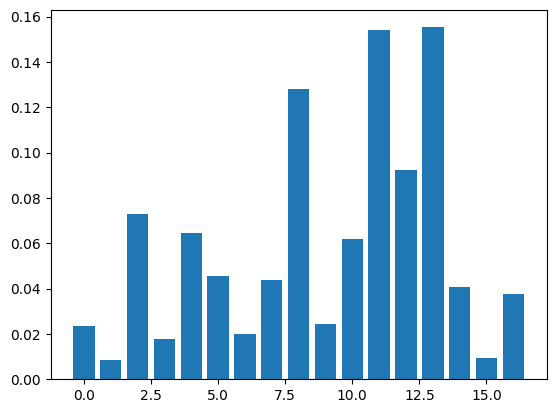

```python
from matplotlib import pyplot
# plot feature importance
pyplot.bar([x for x in range(len(importance))], importance)
pyplot.show()
```

```python
# get variable importance from best XGBoost model
importance = model_rf.feature_importances_
# summarize feature importance
for i,v in enumerate(importance):
 print('Feature: %0d, Score: %.5f' % (i,v))
```

```
Feature: 0, Score: 0.01342
Feature: 1, Score: 0.00201
Feature: 2, Score: 0.03889
Feature: 3, Score: 0.00158
Feature: 4, Score: 0.07829
Feature: 5, Score: 0.02313
Feature: 6, Score: 0.00956
Feature: 7, Score: 0.01446
Feature: 8, Score: 0.37058
Feature: 9, Score: 0.01066
Feature: 10, Score: 0.07301
Feature: 11, Score: 0.10485
Feature: 12, Score: 0.16440
Feature: 13, Score: 0.06920
Feature: 14, Score: 0.02157
Feature: 15, Score: 0.00088
Feature: 16, Score: 0.00351
```

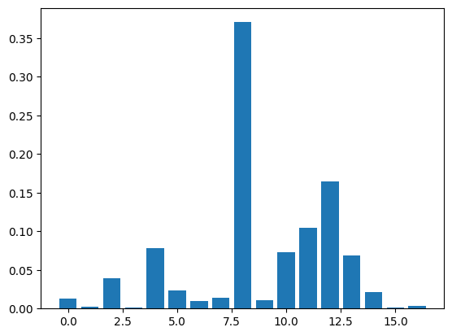

```python
from matplotlib import pyplot
# plot feature importance
pyplot.bar([x for x in range(len(importance))], importance)
pyplot.show()
```

```python
# get variable importance from best XGBoost model
importance = model_ada.feature_importances_
# summarize feature importance
for i,v in enumerate(importance):
 print('Feature: %0d, Score: %.5f' % (i,v))
```

```
Feature: 0, Score: 0.01000
Feature: 1, Score: 0.00000
Feature: 2, Score: 0.03000
Feature: 3, Score: 0.00000
Feature: 4, Score: 0.02000
Feature: 5, Score: 0.00000
Feature: 6, Score: 0.01000
Feature: 7, Score: 0.01000
Feature: 8, Score: 0.08000
Feature: 9, Score: 0.01000
Feature: 10, Score: 0.02000
Feature: 11, Score: 0.01000
Feature: 12, Score: 0.10000
Feature: 13, Score: 0.66000
Feature: 14, Score: 0.03000
Feature: 15, Score: 0.00000
Feature: 16, Score: 0.01000
```

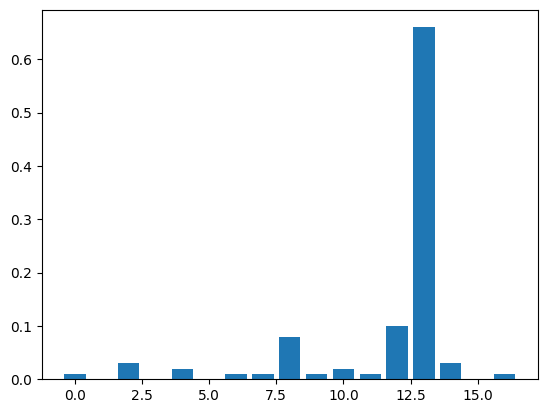

```python
from matplotlib import pyplot
# plot feature importance
pyplot.bar([x for x in range(len(importance))], importance)
pyplot.show()
```